# The KV-Cache — Make Generation Fast Without Changing the Answer

**Builds on `../nanogpt-from-scratch`.** We take that exact trained GPT and add the single most important inference optimization: the **key/value cache**.

By the end you will:

- See *why* naive generation is O(n²) and where the wasted work is
- Build a KV-cache that makes per-step attention O(1) in sequence length → O(n) total
- **Prove** the cache changes speed, not output (logits identical to ~1e-15)
- Measure the real speedup, and see why KV-cache *memory* is the next bottleneck (the link to `../turbo-quant`)

## 0 · The waste: recomputing the past, every step

To generate token *t*, a transformer needs attention over tokens 0…*t*. The naive loop runs a **full forward over the whole prefix every step**:

```
step 1:  [t0]                 → compute K,V for 1 token
step 2:  [t0 t1]              → recompute K,V for t0 (again!) + t1
step 3:  [t0 t1 t2]          → recompute K,V for t0, t1 (again!) + t2
...
```

But the K and V vectors for past tokens **never change** — the weights are fixed and each past token's input is fixed. Recomputing them is pure waste. Total work to emit *n* tokens is 1+2+…+n = **O(n²)**.

```python
import time
import numpy as np
import matplotlib.pyplot as plt
from kvcache import (
    _train_tiny, verify_equivalence, decode_step, KVCache,
    generate_naive, generate_cached,
)

plt.rcParams.update({
    "figure.facecolor": "#0f1117", "axes.facecolor": "#1a1d27",
    "axes.edgecolor": "#2a2d3e", "axes.labelcolor": "#e2e8f0",
    "text.color": "#e2e8f0", "xtick.color": "#94a3b8", "ytick.color": "#94a3b8",
    "axes.titlecolor": "#e2e8f0", "grid.color": "#2a2d3e", "figure.dpi": 110,
})

model, tok = _train_tiny()   # a small GPT trained on a tiny corpus (real weights)
print("model ready — vocab", tok.vocab_size, "| block_size", model.block_size)
```

```
model ready — vocab 14 | block_size 96
```

## 1 · The idea: cache K and V, and the mask disappears

Store each layer's K and V for every past token. To take a step:

1. Compute Q, K, V for **only the new token**.
2. Append its K, V to the cache.
3. Attend the new Q against **all cached K, V**.

Because the cache only ever contains the past, you never build a causal mask — "can't see the future" is automatic. Read `decode_step` in `kvcache.py`: it is one token in, next-token logits out, with the cache carrying the history.

## 2 · Prove it first (the trust moment)

Before trusting a speedup, prove it didn't change the output. `verify_equivalence` runs a full forward and the step-by-step cached path and compares the logits at **every** position.

```python
ids = tok.encode("to be or not to be")
err = verify_equivalence(model, ids)
print(f"max |logit difference| between cached and full forward: {err:.2e}")
print("PASS — identical to machine precision." if err < 1e-6 else "FAIL")
```

```
max |logit difference| between cached and full forward: 8.88e-15
PASS — identical to machine precision.
```

## 3 · The payoff: same text, a fraction of the time

Same seed → both paths generate the **identical string**. Only the cost differs.

```python
prompt = tok.encode("to be")
results = {}
for name, fn in (("naive", generate_naive), ("cached", generate_cached)):
    t0 = time.perf_counter()
    out = fn(model, prompt, 80, np.random.default_rng(7), temperature=0.8)
    results[name] = (time.perf_counter() - t0, tok.decode(out))

for name, (dt, txt) in results.items():
    print(f"{name:6s} {dt*1000:7.1f} ms   {txt[:44]!r}")
print("\nidentical output:", results["naive"][1] == results["cached"][1])
print(f"speedup: {results['naive'][0] / results['cached'][0]:.1f}x")
```

```
naive    164.5 ms   'to be that is the question. to be be be be t'
cached    22.4 ms   'to be that is the question. to be be be be t'

identical output: True
speedup: 7.3x
```

## 4 · Where the O(n²) vs O(n) shows up

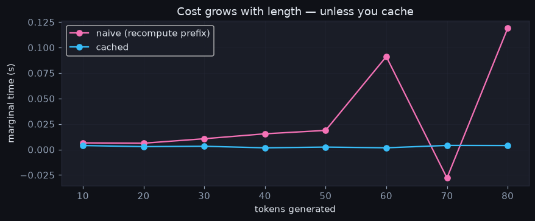

```python
def per_step_times(fn, prompt, n):
    # crude but illustrative: time generating k tokens, difference = marginal cost
    xs, ys, prev = [], [], 0.0
    for k in range(10, n + 1, 10):
        t0 = time.perf_counter()
        fn(model, prompt, k, np.random.default_rng(7))
        tot = time.perf_counter() - t0
        xs.append(k); ys.append((tot - prev)); prev = tot
    return xs, ys

xs, yn = per_step_times(generate_naive, prompt, 80)
_,  yc = per_step_times(generate_cached, prompt, 80)
fig, ax = plt.subplots(figsize=(8, 3.4))
ax.plot(xs, yn, "-o", color="#f472b6", label="naive (recompute prefix)")
ax.plot(xs, yc, "-o", color="#38bdf8", label="cached")
ax.set(title="Cost grows with length — unless you cache",
       xlabel="tokens generated", ylabel="marginal time (s)")
ax.legend(); ax.grid(alpha=0.3); plt.tight_layout(); plt.show()
```

## 5 · The catch: the cache costs memory

The speedup isn't free — you now store K and V for every layer, head, and past token:

```
KV bytes ≈ 2 (K and V) × n_layer × n_head × head_dim × seq_len × batch × dtype_bytes
```

For a real 7B model with long context and big batches, the KV-cache can dwarf the model weights. That is exactly why **KV-cache compression** matters — and why you built `../turbo-quant`: quantizing the cached K/V is one of its headline uses.

```python
def kv_megabytes(n_layer, n_head, head_dim, seq_len, batch, dtype_bytes=2):
    return 2 * n_layer * n_head * head_dim * seq_len * batch * dtype_bytes / 1e6

print("this toy model, 96 tokens, batch 1 :",
      f"{kv_megabytes(2, 4, 16, 96, 1):.3f} MB")
print("a 7B-ish model, 8k tokens, batch 16:",
      f"{kv_megabytes(32, 32, 128, 8192, 16)/1000:.1f} GB  <- bigger than the weights")
```

```
this toy model, 96 tokens, batch 1 : 0.049 MB
a 7B-ish model, 8k tokens, batch 16: 68.7 GB  <- bigger than the weights
```

## 6 · Where next

- **Paged attention** — instead of one contiguous growing array per sequence, store the KV cache in fixed-size *pages* (like OS virtual memory). This is vLLM's core trick; it lets many sequences share GPU memory without fragmentation. Next subfolder: `inference-engine`.
- **KV quantization** — compress cached K/V with `../turbo-quant` and measure the recall hit.
- **Sliding-window / RoPE** — our learned positional embeddings cap context at `block_size`. Rotary embeddings (`../rope`) remove that cap and interact with the cache cleanly.

You now understand the optimization that makes LLM serving affordable — from the inside.

## 7 · Summary

| Piece | Where | Job |
| --- | --- | --- |
| `KVCache` | `kvcache.py` | grow per-layer K/V one token at a time |
| `decode_step` | `kvcache.py` | one token in → next-token logits, using the cache |
| `verify_equivalence` | `kvcache.py` | proof: cached logits == full-forward logits |
| naive vs cached | this notebook | same output, O(n²) vs O(n) cost |

**One line:** cache the past keys and values, compute only the new token, and generation goes from quadratic to linear — with byte-identical output.